# Tableau: North Carolina Teacher Support Program & Duke Pratt School of Engineering Enrollment trends, study away

[Soraya Campbell](https://twitter.com/sorayaworldwide)

2022-05-26

## [NC Teacher Support Program](https://www.fi.ncsu.edu/)

- Stakeholders wanted internal dashboard of KPIs of enrollment, demographic, and coaching support data
- Task was to develop KPIs after EDA, create dashboard with associated visualizations
- Collaborative, contract position through [Friday Institute for Educational Innovation, NCSU](https://www.fi.ncsu.edu/)

## Data

- Excel files extracted from internal database
- Inputs are from more than 100 coaches throughout the state who collected data in the field
  - Each observation was an encounter on a specific date with a teacher enrolled in program
- Notable - coaching support data were in columnar format with each support having multiple levels of data, which in turn needed multi-level pivoting

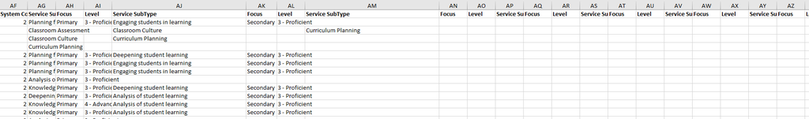

## Cleaning: Tableau Prep

- Because of the multi-level pivot, introduced Tableau Prep Builder to create two extracts of data for analysis
  - One focused on enrollment/demographic info
  - One focused on coaching supports
- Data needed primary key (row id for each encounter; ‘row number’ function) and secondary key (email; created ‘dummy’ email for null values)

## Cleaning: Tableau Prep

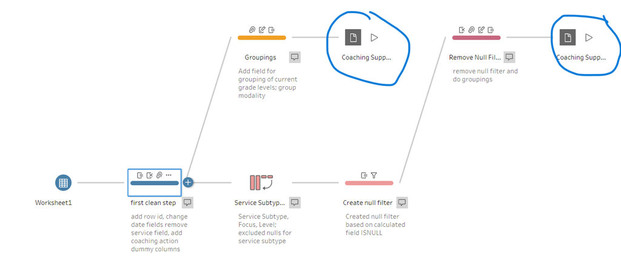

## Cleaning: Tableau Prep

Row id

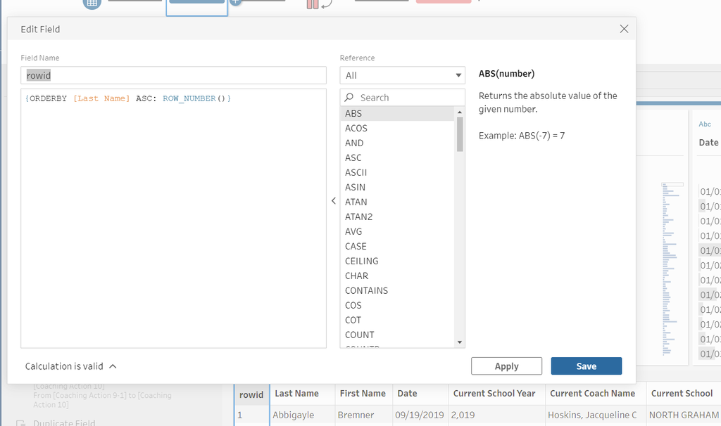

## Cleaning: Tableau Prep

Email

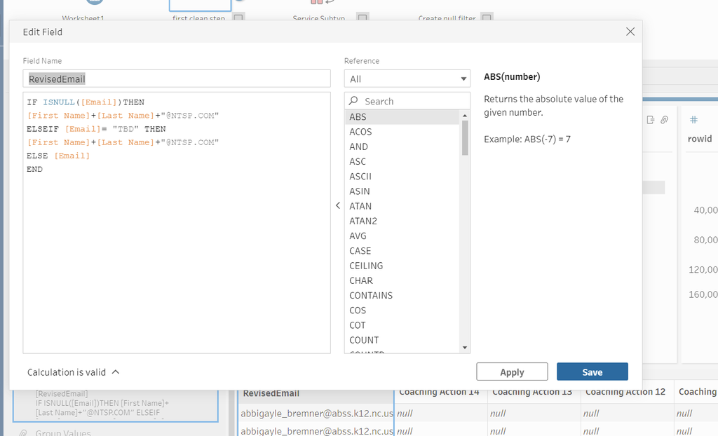

## Cleaning: Tableau Prep

Coaching supports extract - initially 2million rows

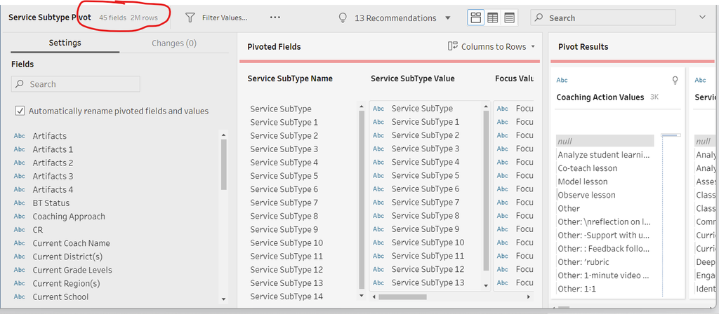

## Cleaning: Tableau Prep

Null filter to reduce amount of empty variables

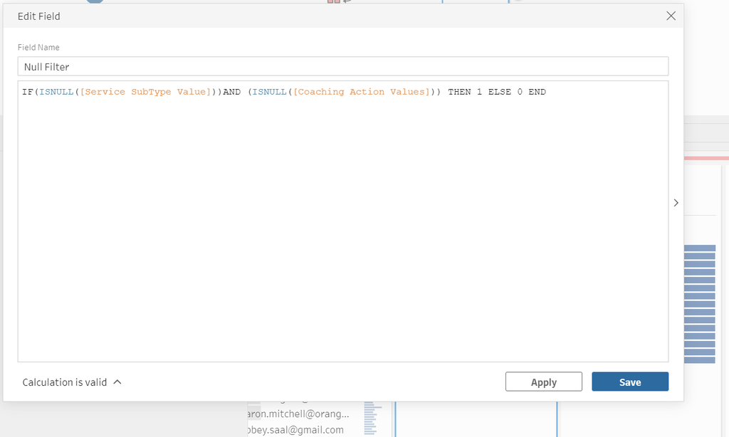

## Cleaning: Tableau Prep

Create null filter

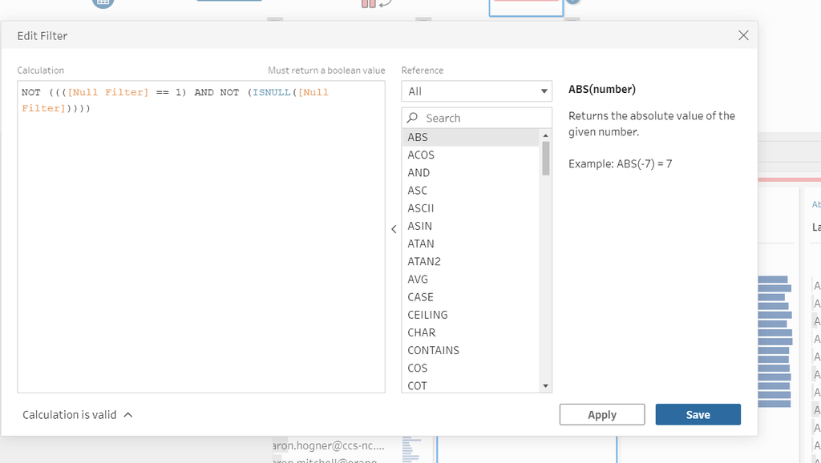

## Cleaning: Tableau Prep

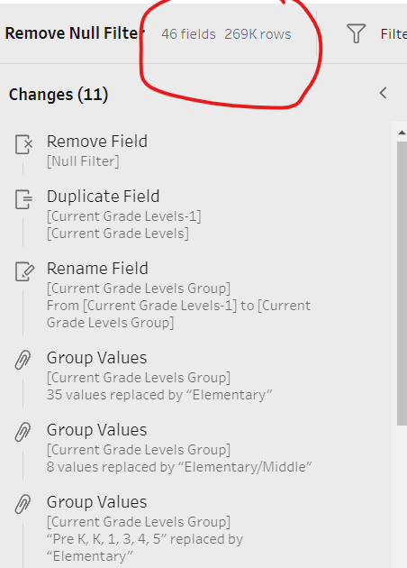

## Exploratory Data Analysis

- After exploring the data extensively via Prep, sought to capture KPIs dealing with time in program, types of supports most heavily used, modality of support, etc.
- Analyses were presented in dashboards that was then organized into a Story
  - Use of color to differentiate focus of dashboards within Story

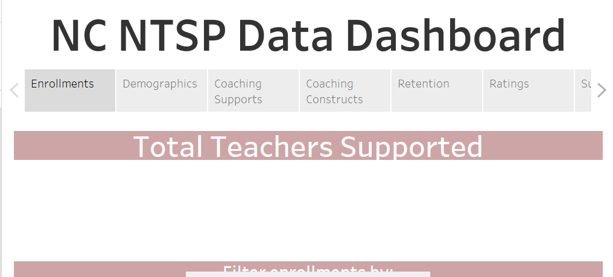

## Story View - Coaching Supports

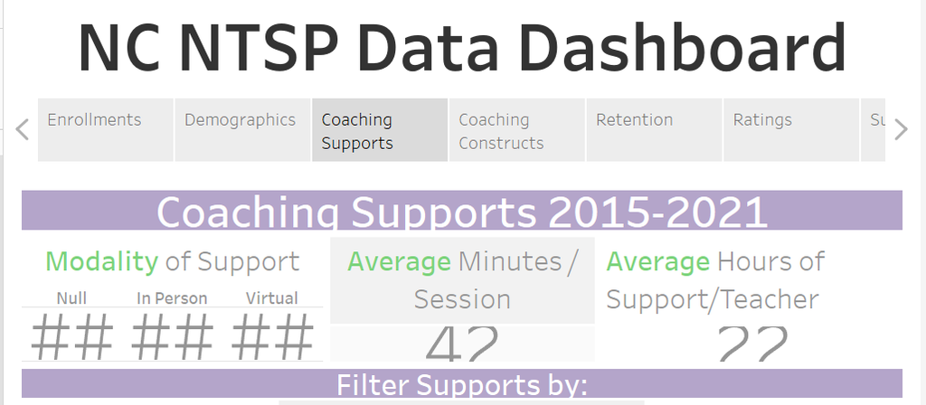

## Story View - Retention

[figure not shown]

## Visualizations

Coaching supports

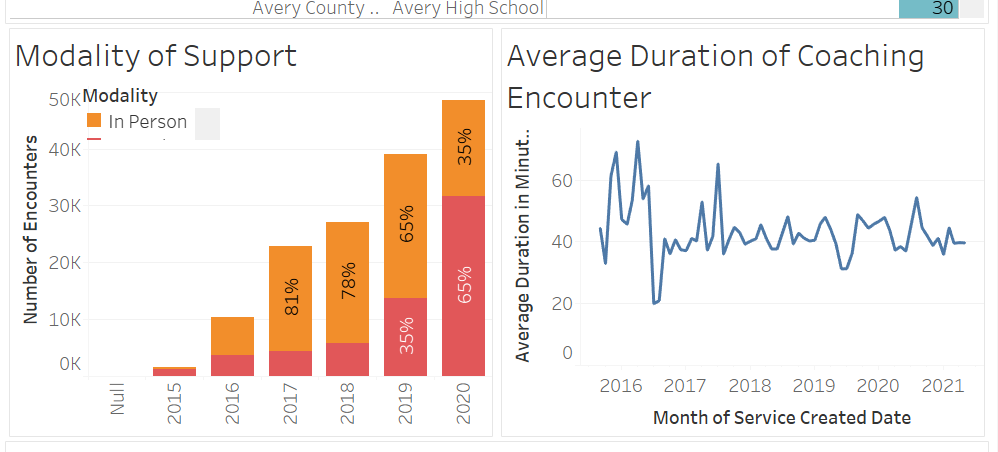

## Visualizations

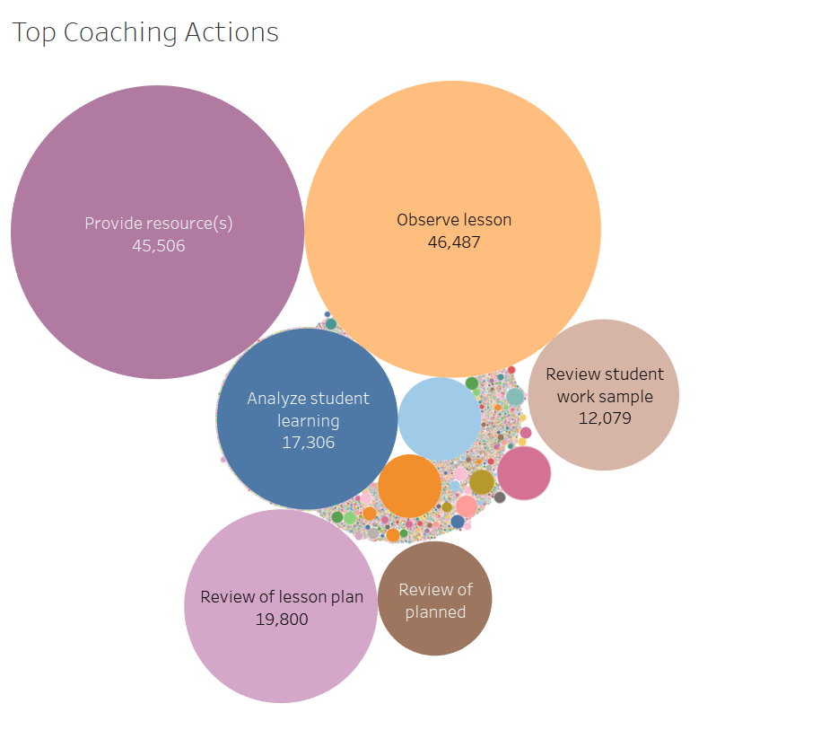

## Calculations

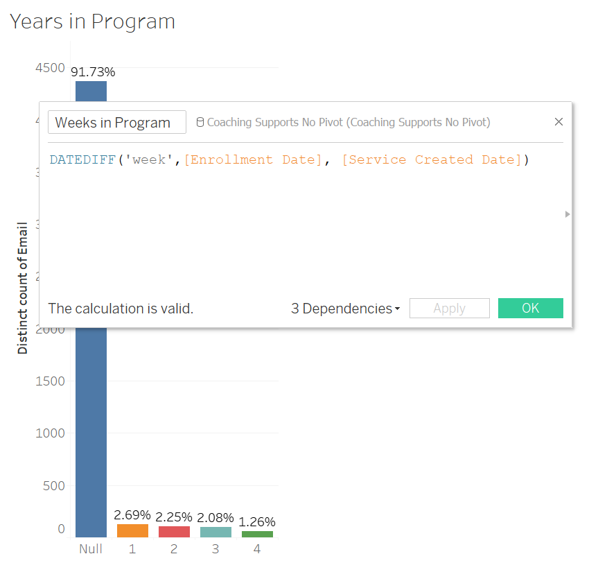

## Calculations

LOD: Fixed

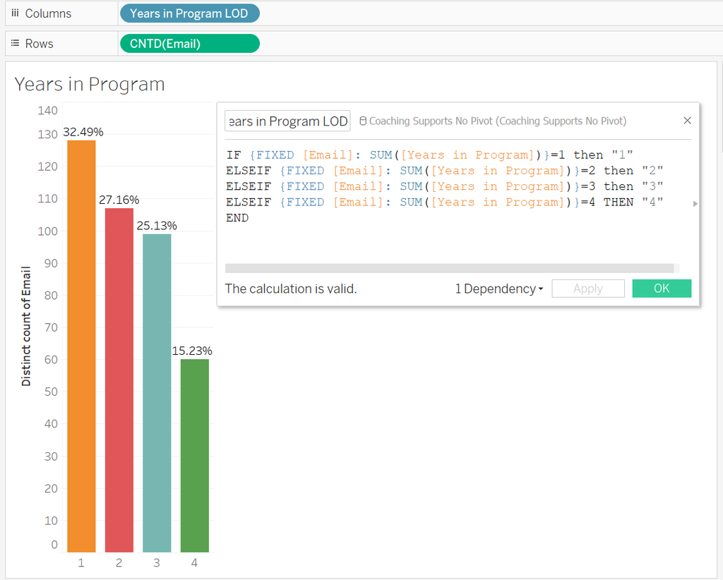

## Key Insights

- Most teachers in program for a year
- More ‘rural’ counties have the worst retention rates
- Most coaching supports consisted of observation and sharing of resources based on observations
- Coaching encounters averaged out to ~40 mins
- Gradual move to virtual encounters through 2019 shifted greatly in 2020 to majority virtual due to pandemic - trend has continued even after initial lockdowns, etc.

## [Pratt School of Engineering:](https://pratt.duke.edu/) Study Away

- [Tableau public dashboard](https://public.tableau.com/app/profile/soraya.campbell/viz/CampbellFinalProject/MainDash)
- Duke has a higher than national average number of engineering/STEM students who study abroad
- Analyzed trends in enrollment, destination, and demographic data
- Interesting trends with female participation
- Most engineering students favor English speaking destinations

## Final thoughts

Visit my portfolio: https://sorayaworldwide.github.io/projects/

Email: sorayacampbell@gmail.com

Connect with me on [LinkedIn](https://www.linkedin.com/in/sorayacampbell/) or [Twitter](https://twitter.com/sorayaworldwide)